# Piece_4

Benjamin Egan

2025-03-03

# Tidy Tuesday - 7/30/2024

The Tidy Tuesday for the week explored movies with “summer” in their title. They scraped the data from IMDB’s website.

```r
tuesdata <- tidytuesdayR::tt_load('2024-07-30')
```

```
## ---- Compiling #TidyTuesday Information for 2024-07-30 ----
## --- There are 2 files available ---
##
##
## ── Downloading files ───────────────────────────────────────────────────────────
##
##   1 of 2: "summer_movie_genres.csv"
##   2 of 2: "summer_movies.csv"
```

```r
summer_movie_genres <- tuesdata$summer_movie_genres
summer_movies <- tuesdata$summer_movies

view(summer_movie_genres)
view(summer_movies)
```

In this Tidy Tuesday, there are two data files, summer_movies_genres, and summer_movies. The data set summer_movies_genres includes unique ID numbers for each film alongside the genre.

## Summer_movie_genres data

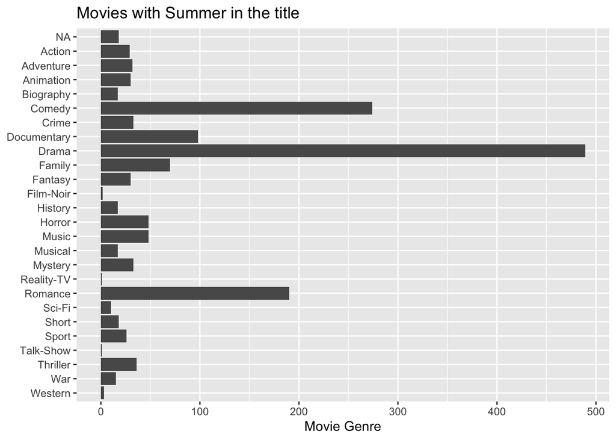

```r
summer_movie_genres %>%
  ggplot(aes(
    x = fct_rev(genres)
  ))+
  coord_flip()+
  geom_bar()+
  labs(
    y = "Movie Genre",
    x = NULL,
    title = "Movies with Summer in the title"
  )
```

We can see that there are a large amount of drama, comedy, and romance films with “Summer” in the title compared to other genres. One category that surprised me were the number of reality shows that don’t have “Summer” in the title. It feels like there would be an appeal to the “Hot, Wet, and Wild” aspect of summer and reality TV.

Update - after looking at movies in the summer_movies dataset as well, the summer_movie_genres places movies with multiple genres in each cateogry.

## Summer_movies data

There appears to be a lot more we can do with the summer_movies dataset. I first started by gathering a summary of what the data set offers.

```r
skim(summer_movies)
```

Data summary

| Name | summer_movies |
| --- | --- |
| Number of rows | 905 |
| Number of columns | 10 |
| _______________________ |  |
| Column type frequency: |  |
| character | 6 |
| numeric | 4 |
| ________________________ |  |
| Group variables | None |

**Variable type: character**

| skim_variable | n_missing | complete_rate | min | max | empty | n_unique | whitespace |
| --- | --- | --- | --- | --- | --- | --- | --- |
| tconst | 0 | 1.00 | 9 | 10 | 0 | 905 | 0 |
| title_type | 0 | 1.00 | 5 | 7 | 0 | 3 | 0 |
| primary_title | 0 | 1.00 | 6 | 83 | 0 | 779 | 0 |
| original_title | 0 | 1.00 | 4 | 70 | 0 | 838 | 0 |
| genres | 18 | 0.98 | 5 | 27 | 0 | 160 | 0 |
| simple_title | 0 | 1.00 | 6 | 80 | 0 | 778 | 0 |

**Variable type: numeric**

| skim_variable | n_missing | complete_rate | mean | sd | p0 | p25 | p50 | p75 | p100 | hist |
| --- | --- | --- | --- | --- | --- | --- | --- | --- | --- | --- |
| year | 1 | 1.00 | 2001.35 | 19.45 | 1920.0 | 1990.0 | 2008.0 | 2016.0 | 2024.0 | ▁▁▂▃▇ |
| runtime_minutes | 56 | 0.94 | 91.04 | 23.85 | 5.0 | 82.0 | 91.0 | 101.0 | 237.0 | ▁▇▅▁▁ |
| average_rating | 0 | 1.00 | 6.27 | 1.25 | 2.3 | 5.6 | 6.4 | 7.1 | 9.8 | ▁▂▇▅▁ |
| num_votes | 0 | 1.00 | 2296.29 | 20630.39 | 10.0 | 34.0 | 119.0 | 517.0 | 564894.0 | ▇▁▁▁▁ |

```r
summary(summer_movies)
```

```
##     tconst           title_type        primary_title      original_title
##  Length:905         Length:905         Length:905         Length:905
##  Class :character   Class :character   Class :character   Class :character
##  Mode  :character   Mode  :character   Mode  :character   Mode  :character
##
##
##
##
##       year      runtime_minutes     genres          simple_title
##  Min.   :1920   Min.   :  5.00   Length:905         Length:905
##  1st Qu.:1990   1st Qu.: 82.00   Class :character   Class :character
##  Median :2008   Median : 91.00   Mode  :character   Mode  :character
##  Mean   :2001   Mean   : 91.04
##  3rd Qu.:2016   3rd Qu.:101.00
##  Max.   :2024   Max.   :237.00
##  NA's   :1      NA's   :56
##  average_rating    num_votes
##  Min.   :2.300   Min.   :    10
##  1st Qu.:5.600   1st Qu.:    34
##  Median :6.400   Median :   119
##  Mean   :6.274   Mean   :  2296
##  3rd Qu.:7.100   3rd Qu.:   517
##  Max.   :9.800   Max.   :564894
##
```

```r
view(summer_movies)
```

Using summary(), I can get basic statistics and identification for each variable.

Using view() and looking up several movies on the IMDB website, I was able to understand more about what the observations for each variable are and why they are present in the dataset. Title_type makes the distinction of what kind of movie it was (movie, TV movie, video, etc.). Primary title is the title in English, original_title is the title in the native language, and simple title takes out all punctuation and excess characters (i.e. apostrophes, colons, semicolons). Genres are all the genres that the movie falls under. This can include multiple categories within one movie. Average_rating is the rating for each movie out of ten, and num_votes is how many people ranked the movie.

## Visualization and exploration

Now that I understand the data I’m working with, I can now begin to show trends and visualizations in the data.

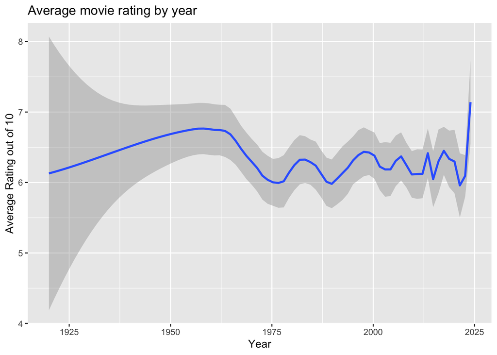

```r
summer_movies %>%
  ggplot(aes(
    x = year,
    y = average_rating
  ))+
  geom_smooth(size = 1,
              span = .15)+
  labs(
    x = "Year",
    y = "Average Rating out of 10",
    title = "Average movie rating by year"
  )
```

The first graph I made shows the trend of movie ratings over time. Since there were few observations before 1950, the trend is not completely accurate. Ignoring this, we can see that the average movie is rated a 6/10. The exception is post 2020, as we can see a sharp spike.

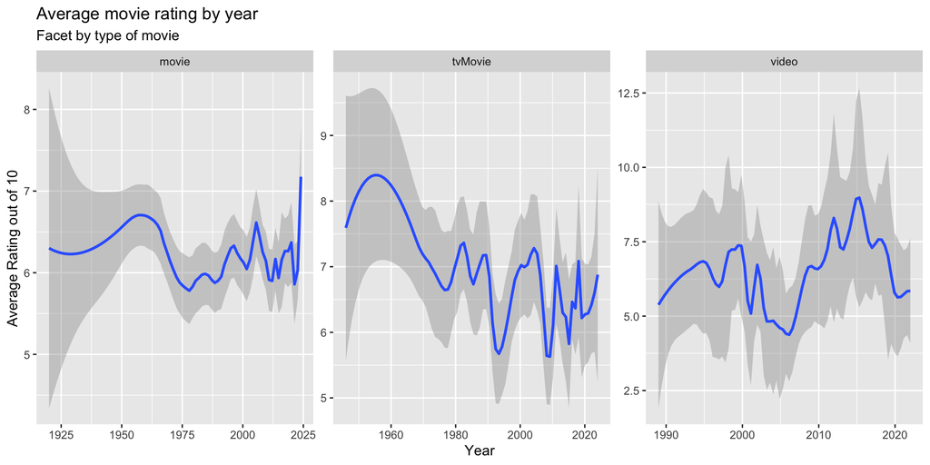

```r
summer_movies %>%
  ggplot(aes(
    x = year,
    y = average_rating
  ))+
  facet_wrap(~title_type, scale = "free")+
  geom_smooth(size = 1,
              span = .15)+
  labs(
    x = "Year",
    y = "Average Rating out of 10",
    title = "Average movie rating by year",
    subtitle = "Facet by type of movie"
  )
```

We can see slight variations in the data when we facet by type of movie. There is a variation in years between the types of movies. Based on history, it makes sense that TV Movies (1950s) and Videos (1990s) started being made later than regular movies. There is also changes in variability for each of the movie types.

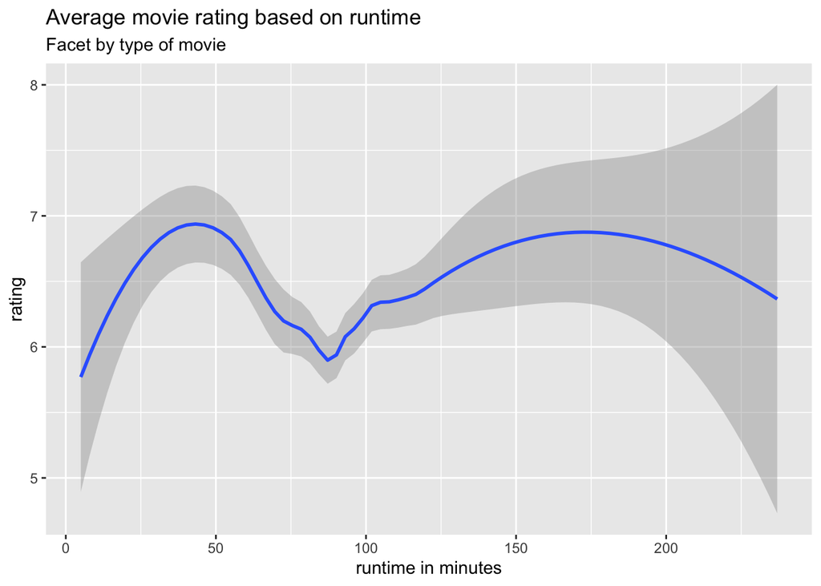

```r
summer_movies %>%
  ggplot(aes(
    y = average_rating,
    x = runtime_minutes
  ))+
  geom_smooth(size = 1,span = .5)+
  labs(
    y = "rating",
    x = "runtime in minutes",
    title = "Average movie rating based on runtime",
    subtitle = "Facet by type of movie"
  )
```

Here I compared run time to rating. There is an interesting bimodality to run time and rating, as movies around the 80 minute run time have lower ratings.

Now I want understand the breakdown by decade for just movies.

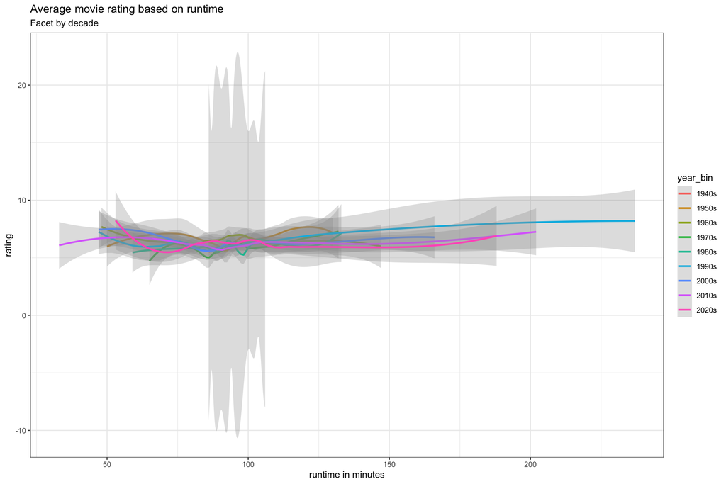

```r
movies_decade <- summer_movies %>%
  mutate(year_bin = case_when(
    year < "1940" ~ "1930s",
    year >= "1940" & year < "1950" ~ "1940s",
    year >= "1950" & year < "1960" ~ "1950s",
    year >= "1960" & year < "1970" ~ "1960s",
    year >= "1970" & year < "1980" ~ "1970s",
    year >= "1980" & year < "1990" ~ "1980s",
    year >= "1990" & year < "2000" ~ "1990s",
    year >= "2000" & year < "2010" ~ "2000s",
    year >= "2010" & year < "2020" ~ "2010s",
    year >= "2020" & year < "2030" ~ "2020s",
  ))

movies_decade <- movies_decade %>%
  filter(
    title_type == "movie"
  )

movies_decade %>%
  ggplot(aes(
    x = runtime_minutes,
    y = average_rating,
    color = year_bin
  ))+
  geom_smooth(size = 1,span = .5, alpha = .3)+
  theme_bw()+
  #facet_wrap(~year_bin, scales = "free")+
  labs(
    x = "runtime in minutes",
    y = "rating",
    title = "Average movie rating based on runtime",
    subtitle = "Facet by decade"
  )
```

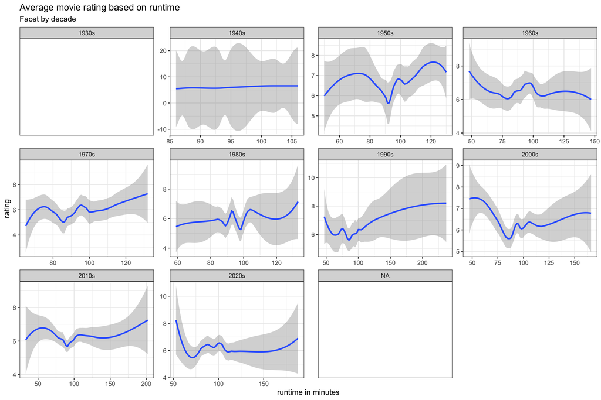

```r
movies_decade %>%
  ggplot(aes(
    x = runtime_minutes,
    y = average_rating
  ))+
  geom_smooth(size = 1,span = .5)+
  theme_bw()+
  facet_wrap(~year_bin, scales = "free")+
  labs(
    x = "runtime in minutes",
    y = "rating",
    title = "Average movie rating based on runtime",
    subtitle = "Facet by decade"
  )
```

Based on using color to distinguish the different decades, it would look like all the decades have extremely similar ratings based on run time. If you facet by decade, it tells you a different story.

There are lots of interesting things to extrapolate from the graph. Although the 1940s has an apparently steady rating over the decade, the shaded region suggests there is a wide amount of variation. We can also see some of the oddball dips and raises that are most likely due to the low amount of run times during that decade.

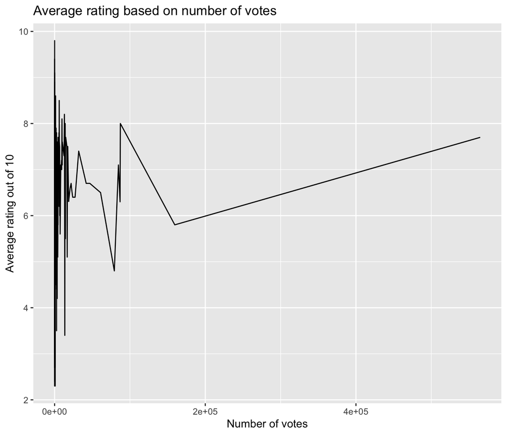

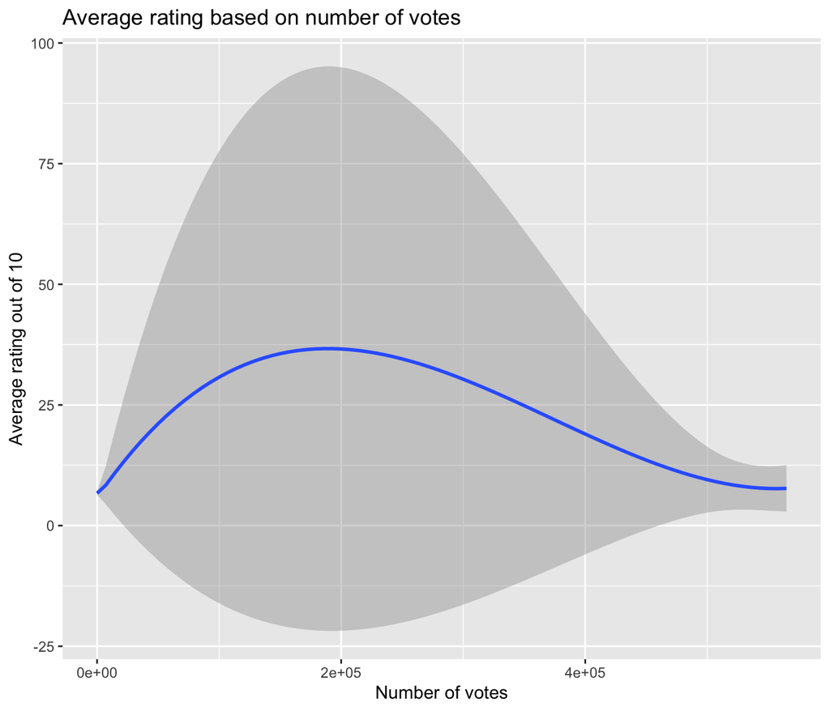

```r
summer_movies %>%
  ggplot(aes(
    x = num_votes,
    y = average_rating
  ))+
  geom_line()+
  labs(
    x = "Number of votes",
    y = "Average rating out of 10",
    title = "Average rating based on number of votes"
  )

summer_movies %>%
  ggplot(aes(
    x = num_votes,
    y = average_rating
  ))+
  geom_smooth()+
   labs(
    x = "Number of votes",
    y = "Average rating out of 10",
    title = "Average rating based on number of votes"
  )
```

This plot was more for my amusement and to understand the difference between geom_line() and geom_smooth(). They provide you two different pictures of what is going on. Using geom_line(), you can tell there is lots of variation in the lower amount of votes, while the votes with an extreme amount of people show an above average rating.

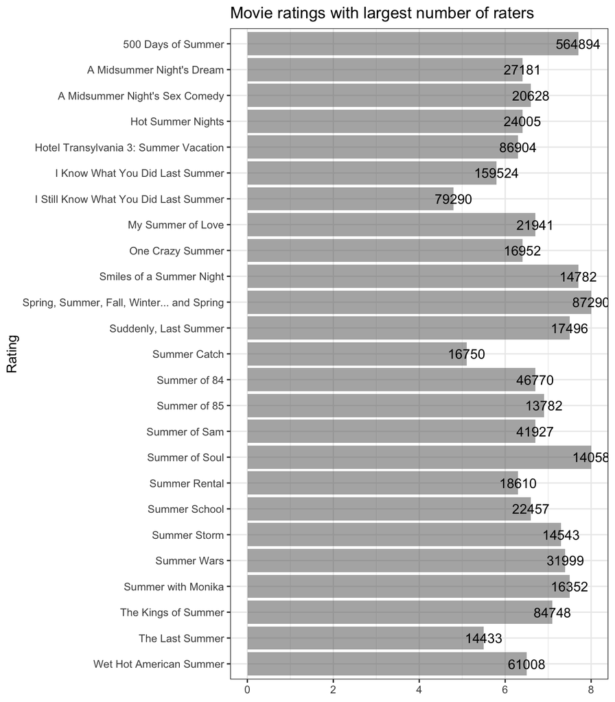

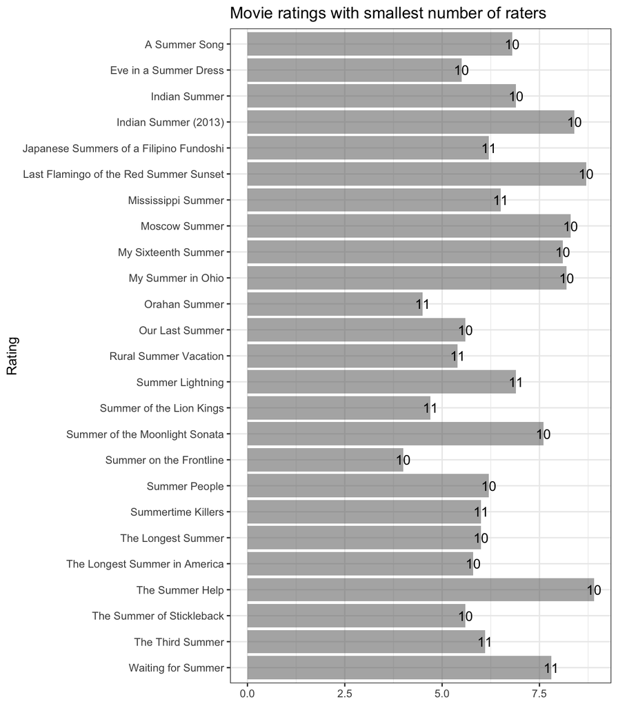

```r
top_bottom_25 <- summer_movies %>%
  filter(
    title_type == "movie"
  )

top_bottom_25 <- top_bottom_25 %>%
mutate(title_last = case_when(
    primary_title == "Indian Summer" & year == "2013" ~ "Indian Summer (2013)",
    primary_title == "Summer of Soul (...Or, When the Revolution Could Not Be Televised)" ~ "Summer of Soul",
    .default = as.character(primary_title)
  ))

top_25 <- top_bottom_25 %>%
   arrange(desc(num_votes)) %>%
    slice(1:25)

top_25 %>%
  ggplot(aes(
    x = fct_rev(title_last),
    y = average_rating
  ))+
  geom_col(alpha = .5)+
  theme_bw()+
  geom_text(aes(x = title_last,
              y = average_rating,
              label = num_votes))+
  coord_flip()+
  labs(
    x = "Rating",
    y = NULL,
    title = "Movie ratings with largest number of raters",
  )





bottom_25 <- top_bottom_25 %>%
   arrange(num_votes) %>%
    slice(1:25)

bottom_25 %>%
  ggplot(aes(
    x = fct_rev(title_last),
    y = average_rating
  ))+
  geom_col(alpha = .5)+
  theme_bw()+
  geom_text(aes(x = title_last,
              y = average_rating,
              label = num_votes))+
  coord_flip()+
  labs(
    x = "Rating",
    y = NULL,
    title = "Movie ratings with smallest number of raters",
  )
```

You can see in the side by side comparision that there is more variability in the bottom 25 rating than in the top 25 ratings for movies.